# Protecting Linked Tables with Non-Nested Hierarchies: A Use Case with rtauargus

uRos2026: The Use of R in Official Statistics

Julien Desclodure

Insee

11/19/2026

## Outline

01

Motivation and tools

02

Detecting Links Between Tables

03

Protecting linked tables with non-nested hierarchies

04

Improving the efficiency of tab_multi_manager()

05

Final words

# 1 Motivation and tools

## 1.1 Context and objectives

Motivation and tools

- Statistical agencies often disseminate multiple related tables describing the same phenomenon.
- Some tables share common cells that must be protected consistently.
- Protecting each table independently may lead to disclosure risks when information is combined across tables.
- The challenge becomes even more complex in the presence of non-nested hierarchies.

**In this presentation, we focus on two contributions:**

1. **Protection:** handling linked tables with non-nested hierarchies using `rtauargus::tab_multi_manager()`.
2. **Performance:** improving its efficiency for large collections of linked tables (100+ tables).

## 1.2 The *rtauargus* package

Motivation and tools

**An R interface to τ-Argus for statistical disclosure control through cell suppression**, enabling seamless integration into R workflows.

- **Input generation:** create `rda`, `arb`, `hst` and `tab` files from R data.
- **Batch execution:** generate instructions (`arb`) and run τ-Argus from the command line.
- **Results retrieval:** import τ-Argus outputs directly into R.

These steps can be performed in a single workflow or independently.

**Additional features**

- Protecting multiple tables simultaneously.
- Building hierarchical variables from correspondence tables.

# 2 Detecting Links Between Tables

## 2.1 Linked tables

Detecting Links Between Tables

**When are tables considered linked?**

Tables are linked when they cover compatible statistical fields and share information that can be combined or used to derive confidential values.

This may occur when:

- They share the same indicator and statistical field:
  - Without common breakdown variables, they share their grand total;
  - With at least one common breakdown variable, they share one or more margins or cells;
  - Their breakdowns may also rely on related hierarchical classifications, creating aggregation relationships between categories across tables.
- Their indicators are connected by a mathematical relationship, allowing values in one table to be derived from values in another.

Tables covering distinct, non-complementary statistical fields are considered independent.

## 2.2 When Hierarchies Overlap

Detecting Links Between Tables

**Non-nested hierarchies**

Different hierarchical classifications may produce overlapping sub-tables, with some cells appearing in several tables.

[figure not shown]

# 3 Protecting linked tables with non-nested hierarchies

## 3.1 `tab_multi_manager()`: A Coordinated Protection of Linked Tables

Protecting linked tables with non-nested hierarchies

The `tab_multi_manager()` function in `rtauargus` provides a framework for managing the protection of multiple linked tables.

**Main principles**

- Managing a collection of linked tables.
- Accounting for common cells shared between tables.
- Ensuring consistent protection decisions across tables.
- Handling of non-nested hierarchies.

## 3.2 Example: turnover by sector and company characteristics

A practical example

Suppose we want to publish company turnover broken down by:

- **Economic activities and company size** (R table `turnover_act_size`);
- **Economic activities and legal form** (R table `turnover_act_lf`).

**Note**

The economic activity classification follows the NAF hierarchy (French Classification of Activities), with three nested levels: **A10 > A21 > A88**. Each level provides a more detailed breakdown of the activities:

- **A10:** 10 broad activity groups;
- **A21:** 21 intermediate activity groups, nested within A10;
- **A88:** 88 detailed activity groups, nested within A21.

## 3.3 Hierarchy from A10 to A21

A practical example

NAF Classification: Hierarchy from A10 to A21 (Activities A–N)

[figure not shown]

Suppose an additional subtotal, named D_TO_M, is also requested. It aggregates activity codes D to M at the A21 level of the NAF classification.

## 3.4 Non-nested hierarchy

A practical example

**What does this additional request change for statistical disclosure control?**

The new subtotal D_TO_M does not fit into the existing hierarchical structure.

For example, activities D and E contribute to two overlapping aggregates BE (A10 level) and D_TO_M (additional subtotal).

We therefore have **non-nested hierarchies**.

[figure not shown]

## 3.5 Building additional tables for protection

A practical example

**Two additional tables must be constructed to account for the new subtotal and ensure consistent protection across all linked tables.**

**1. Turnover by activity and company size**

Starting from `turnover_act_size`, build `turnover_act_size_D_TO_M`, including:

- The existing activity codes from D to M and their A88 subcategories;
- The additional subtotal `D_TO_M`, computed by aggregating activities D to M for each company-size category.

**2. Turnover by activity and legal form**

Similarly, starting from `turnover_act_lf`, build `turnover_act_lf_D_TO_M`.

## 3.6 Preparing the hierarchical files

A practical example

**Two hierarchy files are required to account for the two different hierarchical structures.**

**1. Original NAF hierarchy**

Using `rtauargus::write_hrc2()`, create the hierarchy file `activity.hrc` form a correspondence table of the NAF hierarchy.

- Describes the standard NAF hierarchy (A10 > A21 > A88);
- Used for the original tables: `turnover_act_size` and `turnover_act_lf`.

**2. Additional hierarchy**

Create a second hierarchy file, `activity_DTM.hrc`.

- Describes the additional aggregation `D_TO_M` and its underlying activity levels;
- Used for the additional tables: `turnover_act_size_D_TO_M` and `turnover_act_lf_D_TO_M`.

## 3.7 Applying Primary and Secondary Suppressio n

A practical example

Applying Primary and Secondary Suppression

- Apply primary suppression to each table.
- Handle alternative hierarchies and total codes using:
  - alt_hrc: alternative hierarchy file;
  - alt_totcode: alternative total code.
- Use rtauargus::tab_multi_manager() for joint secondary suppression across linked tables.

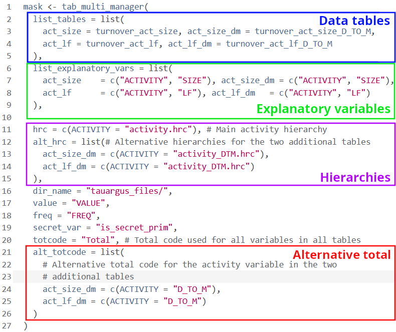

## 3.8 `tab_multi_manager` output on synthetic data

A practical example

`tab_multi_manager` output on synthetic data

We consider a synthetic dataset to illustrate statistical disclosure control on a set of linked tables. Two primary suppression rules are applied:

- **Frequency rule:** cells containing fewer than 3 observations are suppressed.
- **Dominance rule (1; 85%):** cells are suppressed when the largest contributor accounts for more than 85% of the cell’s total value.

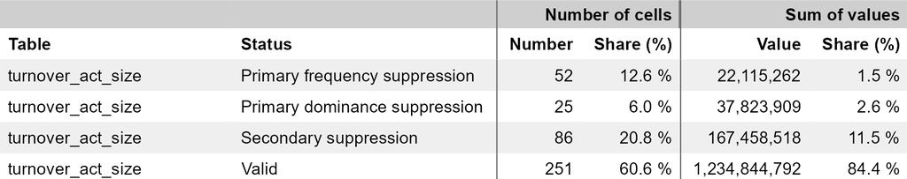

# 4 Improving the efficiency of tab_multi_manager()

## 4.1 Improving the efficiency of tab_multi_manager()

Improving the efficiency of `tab_multi_manager()`

**Optimising the detection of common cells for secondary suppression with vectorised operations**

- Use `rowSums()` to identify cells shared with at least one other table;
- Perform a single row selection instead of multiple extractions and concatenations;
- Avoid duplicate detection and reduce intermediate data-frame creation.

**Impact on processing time**

Information and Communication Technology Survey – 100+ Linked Tables Submitted to Eurostat.

**Before rtauargus 1.3.4:** ~22 hours

**Since rtauargus 1.3.4:** ~2 hours

Approximately 11 times faster

# 5 Final words

## 5.1 Take-home messages

Three main take-home messages

1. Linked tables require coordinated protection.

2. Non-nested hierarchies can be handled with `tab_multi_manager()`.

3. Improvements introduced in `rtauargus` version 1.3.4 enhance the efficiency and scalability of statistical disclosure control for large sets of linked tables.

- Julien Desclodure
- Statistical Disclosure Control Methodologist
- DMGC
- DMCSI
- julien.desclodure@insee.fr
- +33 (0)1 87 69 55 15